# Assignment 14: Writing a function - Loop

Hint: [Similar function](https://bryantstats.github.io/math421/gganimate/14_writing_functions.html#40)

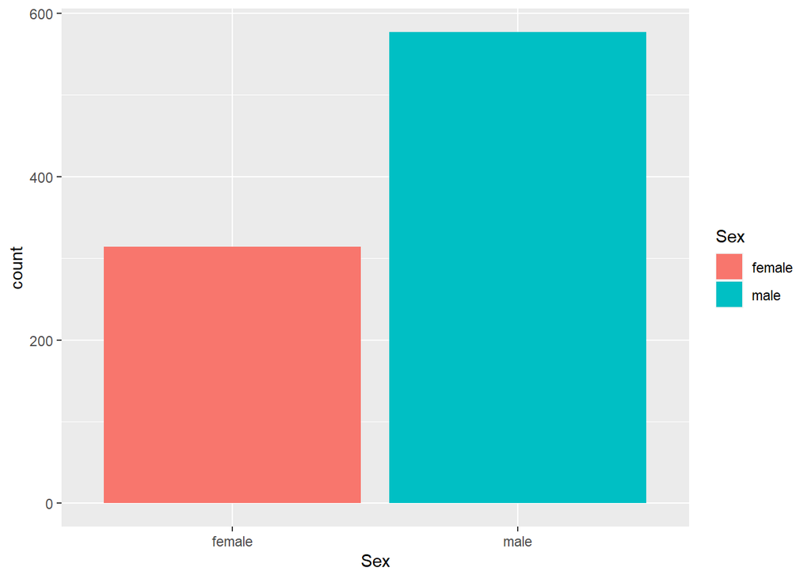

[figure not shown]

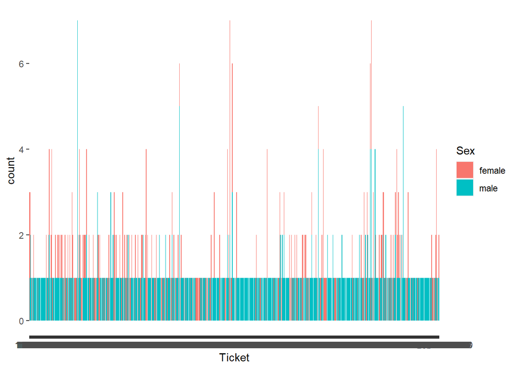

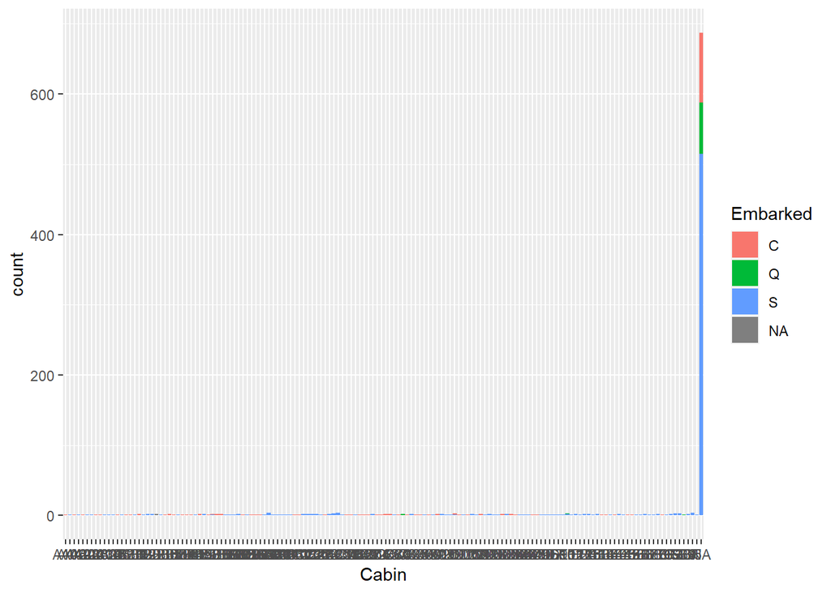

[figure not shown]

[figure not shown]

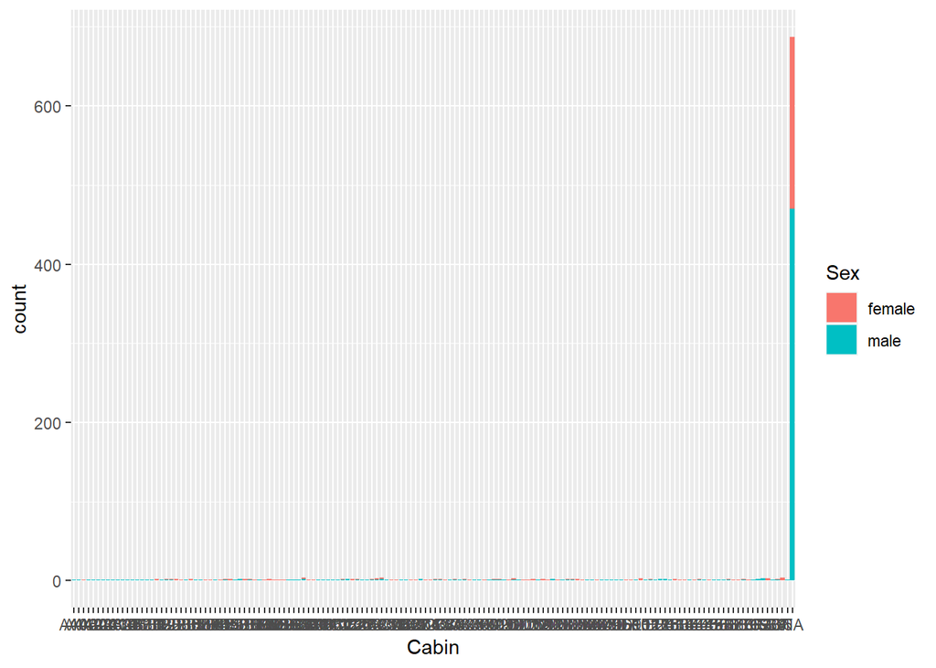

```r
bar_plot2 <- function(d)
{
  library(ggplot2)
  l <- length(d)
  for (i in 1:(l-1))
    for(j in (i+1):1)
    {
      if(!is.numeric(d[[i]])&(!is.numeric(d[[j]])))
      {
        print(ggplot(d, aes(x = d[[i]], fill = d[[j]]))+
                geom_bar()+
                labs(x = names(d)[i], fill = names(d)[j]))
      }
    }
}
bar_plot2(df)
```

5. Write the following function. Give examples to test your function.
- Input: a data frame
- Output:
  - all possible the bar plots of a non-numeric variable filled by a non-numeric variable.
  - all possible the density plots of a numeric variable colored by a non-numeric variable
  - all possible the scatter plots.

Hint: Combine [this function](https://bryantstats.github.io/math421/gganimate/14_writing_functions.html#36), [this function](https://bryantstats.github.io/math421/gganimate/14_writing_functions.html#39), and the function in Question 4. One way to combine is creating a new function, `quick_plot`, and call these three functions within `quic_kplot`.

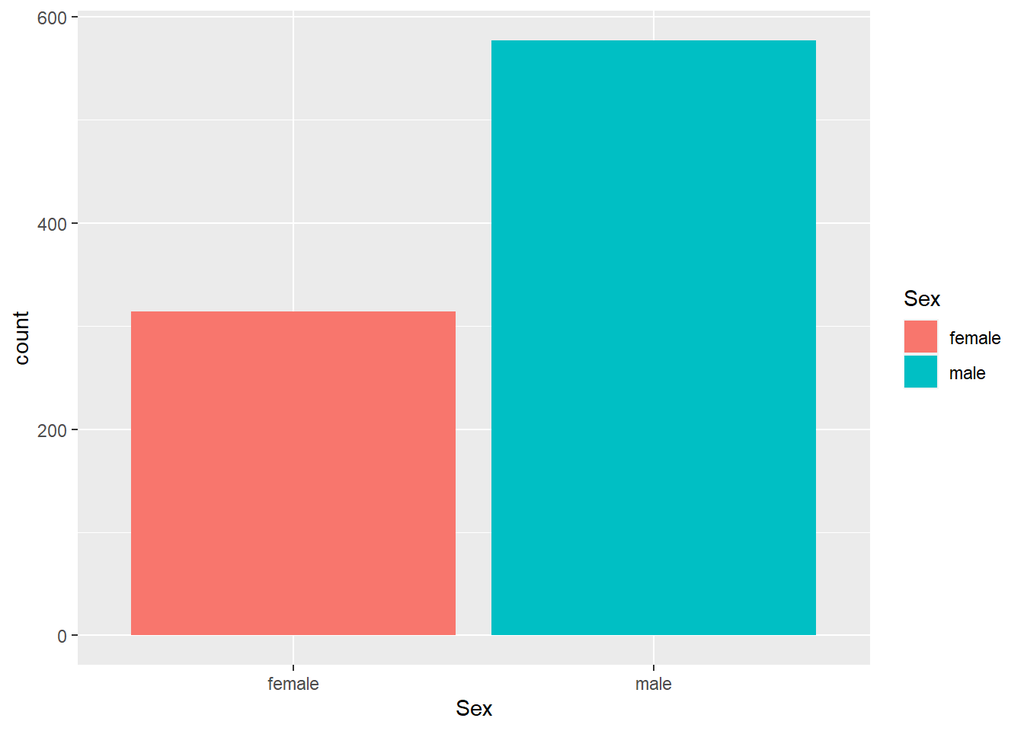

[figure not shown]

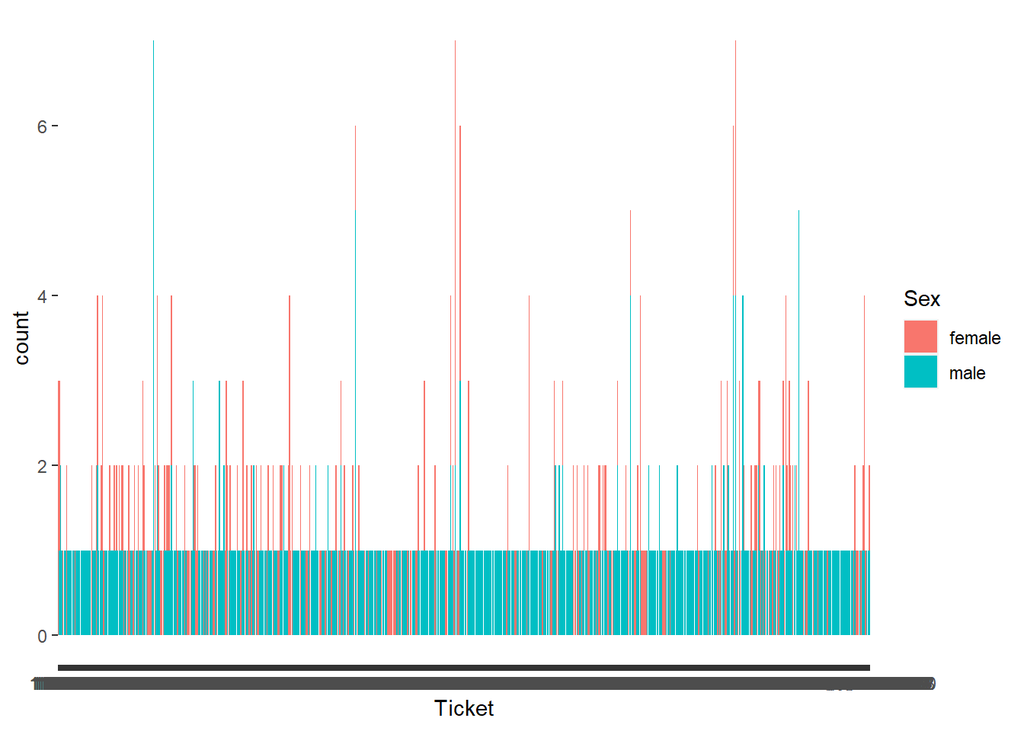

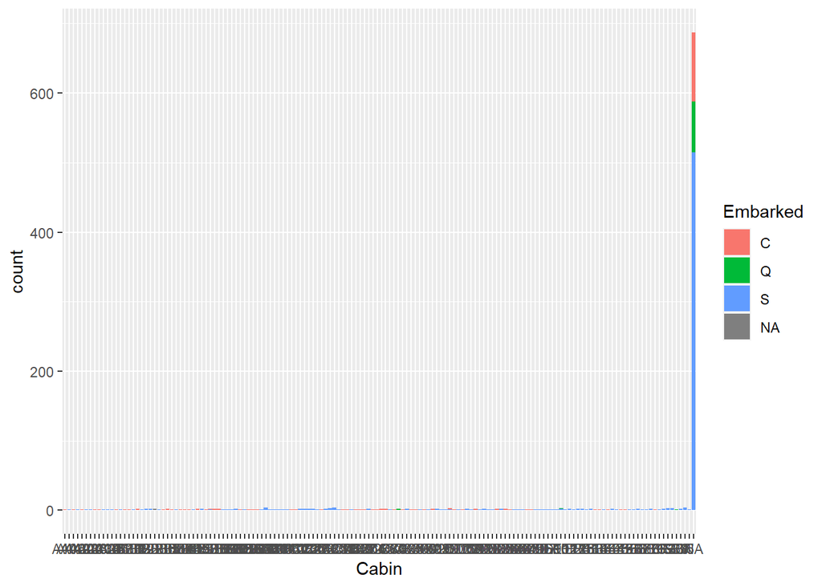

[figure not shown]

[figure not shown]

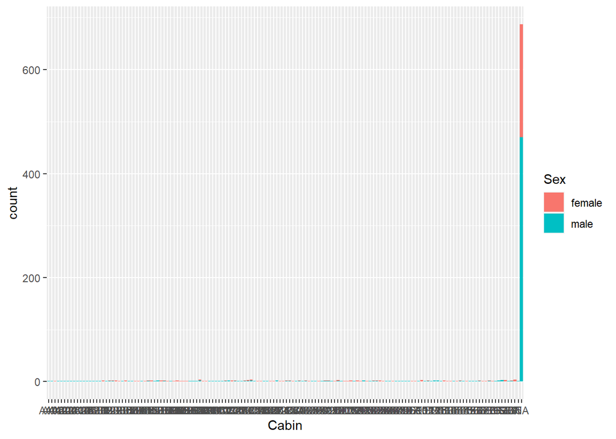

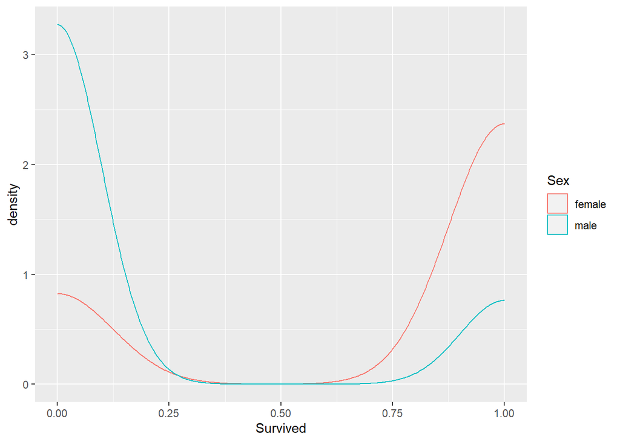

[output not shown]

[output cut: 1038 more lines]

[output not shown]

[output not shown]

[output cut: 1585 more lines]

[output not shown]

[output not shown]

[output cut: 144 more lines]

[output not shown]

[output not shown]

[output cut: 247 more lines]

[output not shown]

[figure not shown]

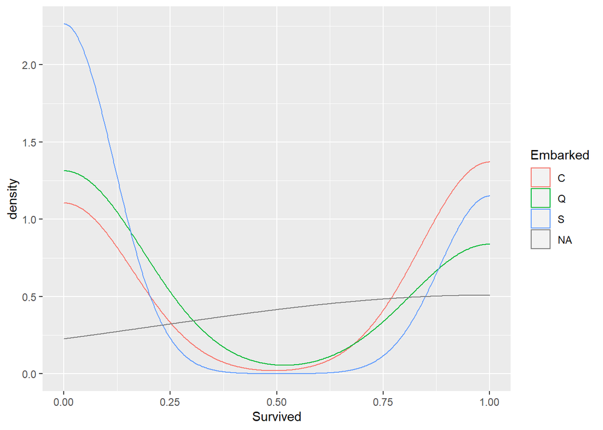

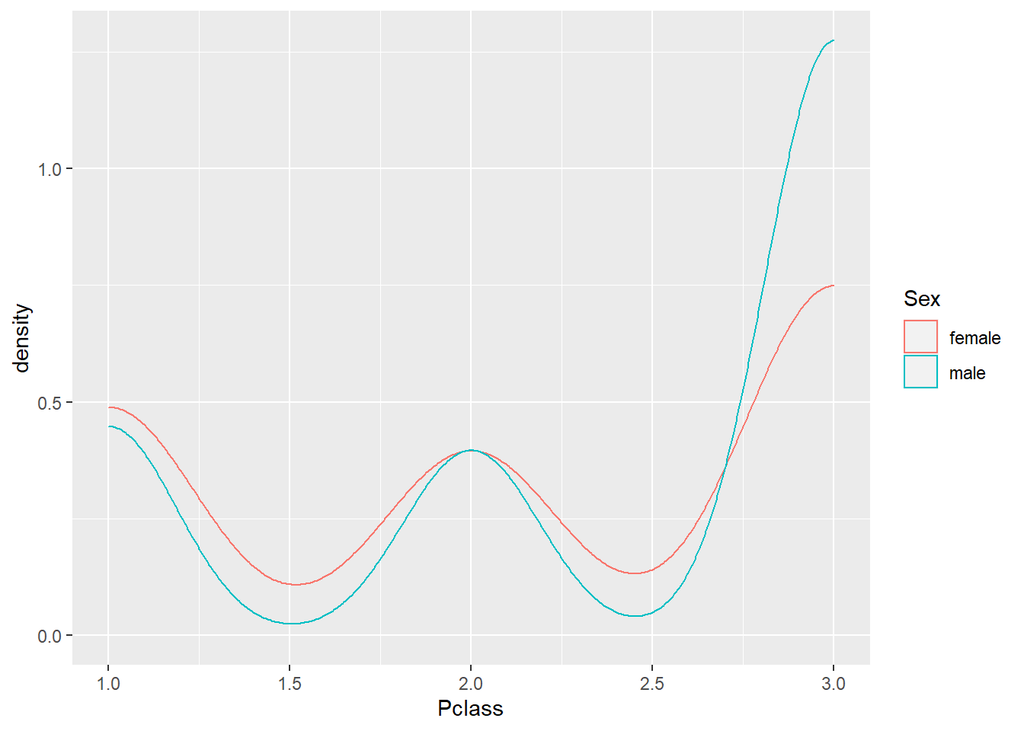

[output not shown]

[output cut: 1036 more lines]

[output not shown]

[output not shown]

[output cut: 1585 more lines]

[output not shown]

[output not shown]

[output cut: 144 more lines]

[output not shown]

[output not shown]

[output cut: 247 more lines]

[output not shown]

[figure not shown]

[25 more figures not shown]

```r
bar_plot2 <- function(d)
{
  library(ggplot2)
  l <- length(d)
  for (i in 1:(l-1))
    for(j in (i+1):1)
    {
      if(!is.numeric(d[[i]])&(!is.numeric(d[[j]])))
      {
        print(ggplot(d, aes(x = d[[i]], fill = d[[j]]))+
                geom_bar()+
                labs(x = names(d)[i], fill = names(d)[j]))
      }
    }
}

density_plot <- function(d)
{
  library(ggplot2)
  l <- length(d)
  for (i in 1:(l-1))
    for (j in (i+1):l)
  {
    if (is.numeric(d[[i]])& (!is.numeric(d[[j]])))
    {
      print(ggplot(d, aes(x = d[[i]], color = d[[j]]))+
              geom_density()+labs(x = names(d)[i], color = names(d)[j]))
    }
  }
}

scatter_plot <- function(d)
{
  library(ggplot2)
  l <- length(d)
  for (i in 1:(l-1))
    for (j in (i+1):l)
  {
    if (is.numeric(d[[i]])&is.numeric(d[[j]]))
    {
      print(ggplot(d, aes(x = d[[i]], y = d[[j]]))+
              geom_point()+
              labs(x = names(d)[i], y = names(d)[j]))
    }
  }
}

quick_plot <- function(x)
{
    bar_plot2(x)
    density_plot(x)
    scatter_plot(x)
}

quick_plot(df)
```